# Introduction à R - s2

31/05/2024

[figure not shown]

[figure not shown]

**L’utilisation :**

Ce document est préparé pour le workshop de R de CERMO-FC. Vous êtes libre de partager et d’utiliser ce matériel, mais veuillez citer la source.

## Rappel et exercices

### Concept logique

```r
a =  (2 - 2) && ((-2:2) >= 0) && ((-2:2) > 0)
```

Voici comment utiliser des opérateurs logiques pour afficher uniquement les valeurs entre 15 et 20 (excluant 15 et 20) du vecteur *vec* :

```r
vec = c(1:100)
```

```r
vecSelect = vec > 15 & vec < 20
vec2 = vec[vecSelect]
```

```r
vec2 = vec[vec > 15 & vec < 20]
```

Génération d’un vecteur de valeurs normalement distribuées :

```r
vecNorm = c(rnorm(200, mean=90, sd=20))
```

Utilisez des opérateurs logiques pour afficher uniquement les valeurs du *vecNorm* inférieures à 60 ou comprises entre 80 et 100 inclusivement :

```r
vecNormSelect = (vecNorm < 60) | (vecNorm >= 80 & vecNorm <= 100)
vecNorm2 = vecNorm[vecNormSelect]
```

### Sélections et conditions

#### Instruction **IF**

La syntaxe de l’instruction *if* est la suivante :

```r
if (condition) {
  instruction
}
```

Si l’expression (condition) est **TRUE**, l’instruction est exécutée. Cependant, si elle est **FALSE**, rien ne se passe.

Ici, la condition peut être un vecteur logique ou numérique.

Diagramme de flux de l’instruction *if* :

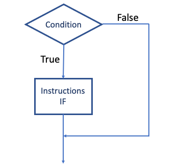

```r
x <- 5
if(x > 0){
  print("positif")
}
```

```
## [1] "positif"
```

#### Instruction **IF…ELSE**

Diagramme de l’instruction *if…else* :

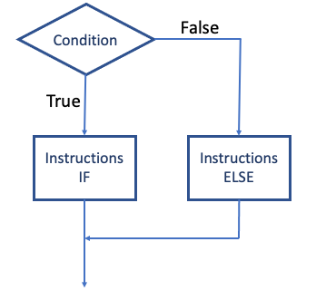

Pour déterminer si un nombre est pair ou impair :

```r
nombre = 5
nombre %% 2 == 0
```

```
## [1] FALSE
```

```r
# if
if(nombre %% 2 == 0) {
  print("Le nombre est pair")
# else
} else {
  print("Le nombre est impair")
}
```

```
## [1] "Le nombre est impair"
```

Pour vérifier si un nombre est positif, négatif ou égal à zéro :

```r
x <- -5
if(x > 0){
  print(paste(x, " positif",sep = ":"))
} else if (x < 0) {
  print(paste(x, "est","négatif", sep = " "))
} else {
  print(paste("x est égal à ", x, sep = ""))
}
```

```
## [1] "-5 est négatif"
```

Pour convertir le vecteur *vecNorm* en un vecteur avec des valeurs entières (en éliminant les décimales) :

```r
a = 77
vecEntier = floor(vecNorm)
if(is.element(a, vecEntier)) {
  print(paste(a, "existe dans vecEntier", sep = " "))
}
```

```
## [1] "77 existe dans vecEntier"
```

Vérifier si un élément **a** existe dans ce vecteur :

```r
any(a == vecEntier)
```

```
## [1] TRUE
```

```r
which(a == vecEntier)
```

```
## [1]   9 128 195
```

```r
match(a, vecEntier)
```

```
## [1] 9
```

```r
a == vecEntier
```

```
##   [1] FALSE FALSE FALSE FALSE FALSE FALSE FALSE FALSE  TRUE FALSE FALSE FALSE FALSE FALSE FALSE FALSE FALSE FALSE FALSE FALSE FALSE FALSE
##  [23] FALSE FALSE FALSE FALSE FALSE FALSE FALSE FALSE FALSE FALSE FALSE FALSE FALSE FALSE FALSE FALSE FALSE FALSE FALSE FALSE FALSE FALSE
##  [45] FALSE FALSE FALSE FALSE FALSE FALSE FALSE FALSE FALSE FALSE FALSE FALSE FALSE FALSE FALSE FALSE FALSE FALSE FALSE FALSE FALSE FALSE
##  [67] FALSE FALSE FALSE FALSE FALSE FALSE FALSE FALSE FALSE FALSE FALSE FALSE FALSE FALSE FALSE FALSE FALSE FALSE FALSE FALSE FALSE FALSE
##  [89] FALSE FALSE FALSE FALSE FALSE FALSE FALSE FALSE FALSE FALSE FALSE FALSE FALSE FALSE FALSE FALSE FALSE FALSE FALSE FALSE FALSE FALSE
## [111] FALSE FALSE FALSE FALSE FALSE FALSE FALSE FALSE FALSE FALSE FALSE FALSE FALSE FALSE FALSE FALSE FALSE  TRUE FALSE FALSE FALSE FALSE
## [133] FALSE FALSE FALSE FALSE FALSE FALSE FALSE FALSE FALSE FALSE FALSE FALSE FALSE FALSE FALSE FALSE FALSE FALSE FALSE FALSE FALSE FALSE
## [155] FALSE FALSE FALSE FALSE FALSE FALSE FALSE FALSE FALSE FALSE FALSE FALSE FALSE FALSE FALSE FALSE FALSE FALSE FALSE FALSE FALSE FALSE
## [177] FALSE FALSE FALSE FALSE FALSE FALSE FALSE FALSE FALSE FALSE FALSE FALSE FALSE FALSE FALSE FALSE FALSE FALSE  TRUE FALSE FALSE FALSE
## [199] FALSE FALSE
```

```r
vecEntier
```

```
##   [1]  71  75  91  69  61 129  71  93  77  51  94 102 101 111 100  94  96  95 100  96  87 136  81  81  97 103 128 114  62 102 125  75 112
##  [34]  87  93  75 104  76  97  74  86  67 112  87  66  91  92  78  71  69  85  65  75 116  76  44  57  38  68 113 110  97  94  89 130 119
##  [67] 113  91  81 101  83  86  80  88  73  74  61  66  89  91  59 113  79  67  93  97 109 112  98 109 101  89  62  85  96  43 133  53  99
## [100] 101  99 111  90  82  85 122 112  95  86 124 101 111 110 103  83 104  97 109 117  73  80  87 105  72  81  67  94  77  84  75  70 147
## [133] 140  94 104 110  92 103  58  99 110  47  75  95  83  94  73 107  46  87 119  85  67  80 108  74  70 118  87  98  78  83 106 101 153
## [166]  81  97  89  61  97  83 120  78 137  81  84  62 124  93  79  75  59 102  82  99  80 102  68  60  79 122  85 109  89  77  64  54 103
## [199] 101  50
```

## Structures de données (suite)

### Matrice

Une matrice est l’équivalent d’un tableau Excel avec des lignes et des colonnes pouvant contenir un seul type de données. Elle est créée à partir d’un vecteur auquel des dimensions ont été attribuées.

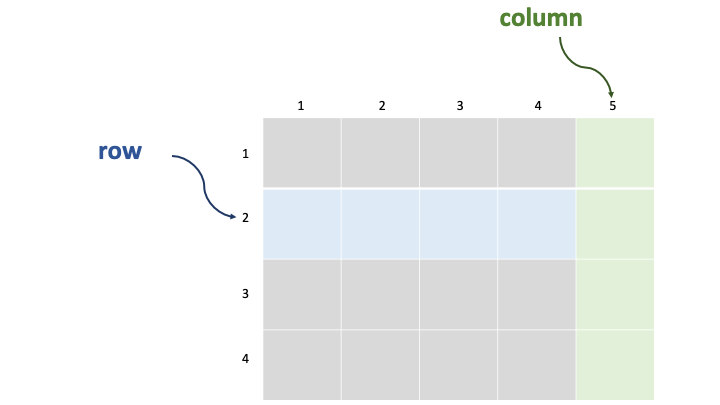

```r
maMatrice_1 = matrix(nrow = 4, ncol = 5, 10:29)
maMatrice_1
```

```
##      [,1] [,2] [,3] [,4] [,5]
## [1,]   10   14   18   22   26
## [2,]   11   15   19   23   27
## [3,]   12   16   20   24   28
## [4,]   13   17   21   25   29
```

```r
vec = 1:15
matx = matrix(vec,5,3)
matx
```

```
##      [,1] [,2] [,3]
## [1,]    1    6   11
## [2,]    2    7   12
## [3,]    3    8   13
## [4,]    4    9   14
## [5,]    5   10   15
```

Pour créer une matrice *NULL* de taille spécifique :

```r
matxB = matrix(NA,nrow=3,ncol=3)
matxB
```

```
##      [,1] [,2] [,3]
## [1,]   NA   NA   NA
## [2,]   NA   NA   NA
## [3,]   NA   NA   NA
```

Vous pouvez obtenir une ou plusieurs lignes et/ou colonnes directement avec l’indexation **[ligne, colonne]** :

```r
maMatrice_1[1,2]
```

```
## [1] 14
```

```r
maMatrice_2 = maMatrice_1[1:3,3:4]
maMatrice_2
```

```
##      [,1] [,2]
## [1,]   18   22
## [2,]   19   23
## [3,]   20   24
```

Pour lister toutes les lignes sauf la ligne 3, nous utilisons la syntaxe suivante :

```r
maMatrice_2[-3,]
```

```
##      [,1] [,2]
## [1,]   18   22
## [2,]   19   23
```

R dispose d’une fonction `summary()` qui fournit des statistiques de base :

```r
summary(maMatrice_1)
```

```
##        V1              V2              V3              V4              V5
##  Min.   :10.00   Min.   :14.00   Min.   :18.00   Min.   :22.00   Min.   :26.00
##  1st Qu.:10.75   1st Qu.:14.75   1st Qu.:18.75   1st Qu.:22.75   1st Qu.:26.75
##  Median :11.50   Median :15.50   Median :19.50   Median :23.50   Median :27.50
##  Mean   :11.50   Mean   :15.50   Mean   :19.50   Mean   :23.50   Mean   :27.50
##  3rd Qu.:12.25   3rd Qu.:16.25   3rd Qu.:20.25   3rd Qu.:24.25   3rd Qu.:28.25
##  Max.   :13.00   Max.   :17.00   Max.   :21.00   Max.   :25.00   Max.   :29.00
```

Modifier un seul élément :

```r
maMatrice_1[1,2] = 0
```

Modifier les éléments inférieurs à 5 à 100 :

```r
maMatrice_1[maMatrice_1 < 5] = 100
```

Modifier les éléments inférieurs à 20 ou supérieurs à 28 à 100 :

```r
maMatrice_1[maMatrice_1 < 20 | maMatrice_1 > 28] = 100
```

Modifier plusieurs éléments par position :

```r
maMatrice_1[c(1,3), c(2,5)] = 20
```

#### Transposer une matrice

Pour échanger les lignes et les colonnes:

```r
dim(maMatrice_1)
```

```
## [1] 4 5
```

```r
matrice_t = t(maMatrice_1)
matrice_t
```

```
##      [,1] [,2] [,3] [,4]
## [1,]  100  100  100  100
## [2,]   20  100   20  100
## [3,]  100  100   20   21
## [4,]   22   23   24   25
## [5,]   20   27   20  100
```

#### Ajouter des lignes à une matrice (`rbind()`)

Le nom de la fonction R `rbind()` signifie “row-bind”. Cette fonction peut être utilisée pour combiner plusieurs vecteurs et/ou matrices par ligne.

```r
x = c(2,6,4,1)
y = c(9,5,7,2)
z = c(3,0,8,5)
mr = rbind(x,y,z)
mr
```

```
##   [,1] [,2] [,3] [,4]
## x    2    6    4    1
## y    9    5    7    2
## z    3    0    8    5
```

```r
matxMR = rbind(matx , mr)
```

```
## Error in rbind(matx, mr): number of columns of matrices must match (see arg 2)
```

```r
matxMR = rbind(matx , t(mr))
# OU
matxMR2 = rbind(matx , mr[,1:3])
# OU
matxMR3 = rbind(matx , mr[,-2])
```

#### Ajouter des colonnes à une matrice (`cbind()`)

Pour ajouter des colonnes à une matrice, on utilise la fonction `cbind()`. Ajouter une colonne de caractères à la matrice `matxMR` (vous pouvez utiliser le vecteur d’alphabet en majuscules) :

```r
matxMRC1 = cbind(matxMR, LETTERS[1:9])
# OU
matxMRC2 = cbind(matxMR, LETTERS[1:nrow(matxMR)])

matxMRC1 == matxMRC2
```

```
##          x    y    z
##  [1,] TRUE TRUE TRUE TRUE
##  [2,] TRUE TRUE TRUE TRUE
##  [3,] TRUE TRUE TRUE TRUE
##  [4,] TRUE TRUE TRUE TRUE
##  [5,] TRUE TRUE TRUE TRUE
##  [6,] TRUE TRUE TRUE TRUE
##  [7,] TRUE TRUE TRUE TRUE
##  [8,] TRUE TRUE TRUE TRUE
##  [9,] TRUE TRUE TRUE TRUE
```

#### Modification des noms des lignes et des colonnes

```r
colnames(matxMRC2) = c("x", "y", "z", "l")
rownames(matxMRC2) = letters[1:9]

matxMRC2
```

```
##   x   y    z    l
## a "1" "6"  "11" "A"
## b "2" "7"  "12" "B"
## c "3" "8"  "13" "C"
## d "4" "9"  "14" "D"
## e "5" "10" "15" "E"
## f "2" "9"  "3"  "F"
## g "6" "5"  "0"  "G"
## h "4" "7"  "8"  "H"
## i "1" "2"  "5"  "I"
```

### Data frame

Un data frame est l’équivalent d’un tableau Excel, composé de lignes et de colonnes, pouvant contenir différents types de données :

```r
patients <- data.frame(age = c(50:59), poids = c(75:84), groupe = rep(c("control","treated"), each = 1, times = 5))
patients
```

```
##    age poids  groupe
## 1   50    75 control
## 2   51    76 treated
## 3   52    77 control
## 4   53    78 treated
## 5   54    79 control
## 6   55    80 treated
## 7   56    81 control
## 8   57    82 treated
## 9   58    83 control
## 10  59    84 treated
```

### Le symbole `$` vous permet d’accéder au contenu d’une colonne dans un data frame par le nom de colonne

```r
patients$poids
```

```
##  [1] 75 76 77 78 79 80 81 82 83 84
```

Le contenu de la colonne *groupe* :

```r
patients$groupe
```

```
##  [1] "control" "treated" "control" "treated" "control" "treated" "control" "treated" "control"
## [10] "treated"
```

Une autre façon est d’utiliser le nom de la colonne entre crochets :

```r
patients["groupe"]
```

```
##     groupe
## 1  control
## 2  treated
## 3  control
## 4  treated
## 5  control
## 6  treated
## 7  control
## 8  treated
## 9  control
## 10 treated
```

`class()` indique le type d’un objet :

```r
class(patients)
```

```
## [1] "data.frame"
```

`dim()` indique la dimension des données :

```r
dim(patients)
```

```
## [1] 10  3
```

Autres fonctions importantes :

```r
colnames(patients)
```

```
## [1] "age"    "poids"  "groupe"
```

```r
rownames(patients)
```

```
##  [1] "1"  "2"  "3"  "4"  "5"  "6"  "7"  "8"  "9"  "10"
```

Vous pouvez modifier les noms des colonnes :

```r
colnames(patients) = c("col1","col2","col3")
colnames(patients)
```

```
## [1] "col1" "col2" "col3"
```

```r
colnames(patients) = c("age","poids","groupe")
colnames(patients)
```

```
## [1] "age"    "poids"  "groupe"
```

### Ajout de données au data frame

```r
patients$poidsLB = patients$poids / 0.45359237
patients
```

```
##    age poids  groupe  poidsLB
## 1   50    75 control 165.3467
## 2   51    76 treated 167.5513
## 3   52    77 control 169.7559
## 4   53    78 treated 171.9606
## 5   54    79 control 174.1652
## 6   55    80 treated 176.3698
## 7   56    81 control 178.5744
## 8   57    82 treated 180.7791
## 9   58    83 control 182.9837
## 10  59    84 treated 185.1883
```

## Accès et sélection des données dans un data frame

Vous pouvez accéder à une ou plusieurs lignes et/ou colonnes directement en utilisant la notation `[ligne, colonne]` :

```r
patients[2,]
```

```
##   age poids  groupe  poidsLB
## 2  51    76 treated 167.5513
```

```r
patients[,3]
```

```
##  [1] "control" "treated" "control" "treated" "control" "treated" "control" "treated" "control"
## [10] "treated"
```

```r
patients[1:3,3]
```

```
## [1] "control" "treated" "control"
```

```r
patients[c(1,3,5), c(2,4)]
```

```
##   poids  poidsLB
## 1    75 165.3467
## 3    77 169.7559
## 5    79 174.1652
```

Pour lister toutes les lignes sauf la ligne 5, nous utilisons la syntaxe suivante :

```r
patients[-5,]
```

```
##    age poids  groupe  poidsLB
## 1   50    75 control 165.3467
## 2   51    76 treated 167.5513
## 3   52    77 control 169.7559
## 4   53    78 treated 171.9606
## 6   55    80 treated 176.3698
## 7   56    81 control 178.5744
## 8   57    82 treated 180.7791
## 9   58    83 control 182.9837
## 10  59    84 treated 185.1883
```

De la même manière, pour lister toutes les colonnes sauf la colonne 1, nous faisons :

```r
patients[,-1]
```

```
##    poids  groupe  poidsLB
## 1     75 control 165.3467
## 2     76 treated 167.5513
## 3     77 control 169.7559
## 4     78 treated 171.9606
## 5     79 control 174.1652
## 6     80 treated 176.3698
## 7     81 control 178.5744
## 8     82 treated 180.7791
## 9     83 control 182.9837
## 10    84 treated 185.1883
```

```r
date = c("2022-05-14", "2022-05-15", "2022-05-16", "2022-05-17")
new = c("296180", "392920", "269510", "232880")
record = c("252,400", "152,600", "170,460", "205,630")
death = c(15, 8, 6, 6)
df = data.frame(date, new, record, death)
```

```r
str(df)
```

```
## 'data.frame':    4 obs. of  4 variables:
##  $ date  : chr  "2022-05-14" "2022-05-15" "2022-05-16" "2022-05-17"
##  $ new   : chr  "296180" "392920" "269510" "232880"
##  $ record: chr  "252,400" "152,600" "170,460" "205,630"
##  $ death : num  15 8 6 6
```

Si nous voulons calculer la somme des nouveaux cas ou la somme cumulée des nouveaux cas en utilisant la somme de `df[, 'new']`, nous obtiendrons une erreur. Pourquoi ?

```r
sum(df[, 2])
```

```
## Error in sum(df[, 2]): invalid 'type' (character) of argument
```

```r
# OU
sum(df[, 'new'])
```

```
## Error in sum(df[, "new"]): invalid 'type' (character) of argument
```

```r
# OU
sum(df$new)
```

```
## Error in sum(df$new): invalid 'type' (character) of argument
```

```r
class(df$new)
```

```
## [1] "character"
```

Pour convertir les nombres au format numérique, on utilise la fonction *as.numeric()* :

```r
df$new = as.numeric(df$new)
# df$new = as.numeric(df[, 'new'])
df
```

```
##         date    new  record death
## 1 2022-05-14 296180 252,400    15
## 2 2022-05-15 392920 152,600     8
## 3 2022-05-16 269510 170,460     6
## 4 2022-05-17 232880 205,630     6
```

```r
class(df$new)
```

```
## [1] "numeric"
```

```r
sum(df[, 'new'])
```

```
## [1] 1191490
```

Filtrer les données en fonction de critères spécifiques :

```r
patients$groupe
```

```
##  [1] "control" "treated" "control" "treated" "control" "treated" "control" "treated" "control"
## [10] "treated"
```

```r
patients$groupe == "control"
```

```
##  [1]  TRUE FALSE  TRUE FALSE  TRUE FALSE  TRUE FALSE  TRUE FALSE
```

```r
patients[patients$groupe == "control",]
```

```
##   age poids  groupe  poidsLB
## 1  50    75 control 165.3467
## 3  52    77 control 169.7559
## 5  54    79 control 174.1652
## 7  56    81 control 178.5744
## 9  58    83 control 182.9837
```

```r
patients[patients$groupe == "control" & patients$age < 60,]
```

```
##   age poids  groupe  poidsLB
## 1  50    75 control 165.3467
## 3  52    77 control 169.7559
## 5  54    79 control 174.1652
## 7  56    81 control 178.5744
## 9  58    83 control 182.9837
```

## Fin de la session 2

**Références:**

Ce document est basé sur les notes de cours “Course_1_intro_R” (préparé par Golrokh Kiani) ainsi que sur du matériel gratuit sur internet:

https://www.tutorialspoint.com  
https://scilifelab.github.io/courses/r_programming/1611/Exercises/Vectors  
https://www.r-exercises.com  
https://www.datamentor.io/r-programming/  
https://training.computeontario.ca  
https://www.w3schools.com/  
http://www.r-tutor.com/